# Size dimorphism estimation, confidence intervals, and significance tests with `dimorph`

### 5.2.4 Plotting

Plotting is exactly the same for multivariate significance tests as it is for the univariate case. Using `plot()` generates histograms for the resampled values using the first methods combination in the `SSDtest` object.

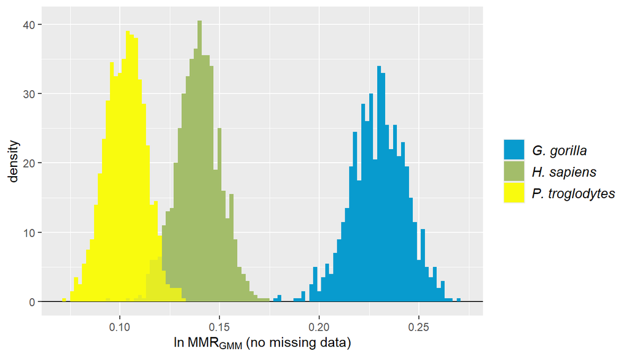

```r
plot(test_fossil_multi)
```

Note that the x-axis label reports the univariate method, the multivariate method as a subscript, and whether or not the missing data structure was imposed in parentheses. This first method combination uses complete data and does not impose the missing data pattern, so dimorphism isn’t estimated for the fossil sample in this case. We can take a look at the resampled distributions using the missing data structure by changing the estimate that’s plotted (argument `est`).

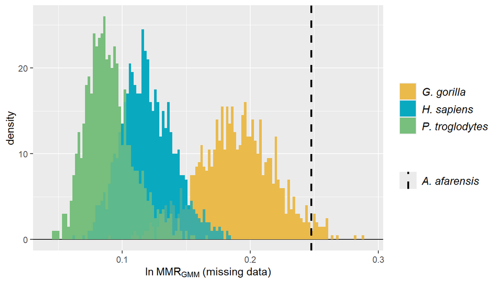

```r
plot(test_fossil_multi, est=2, # plot the 2nd method combination: MMR, GMM, "missing" datastructure
     groupcols=speciescolors) # use our previously specified color vector
```

As in the univariate case, the distributions of differences in resampled values can also be plotted.

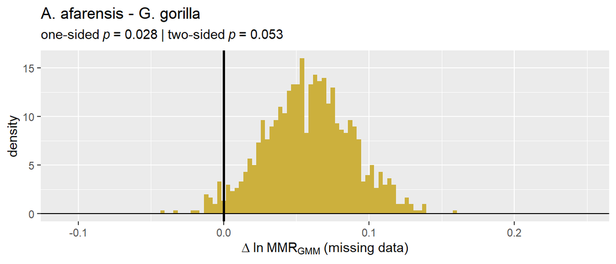

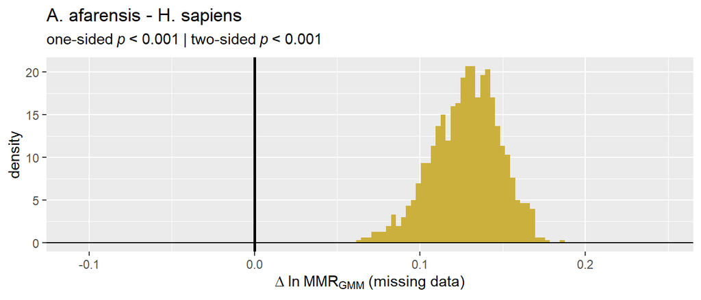

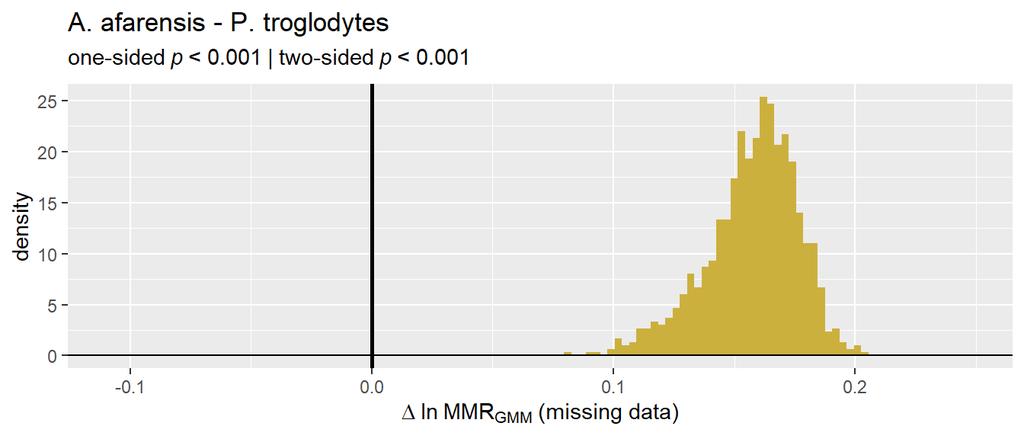

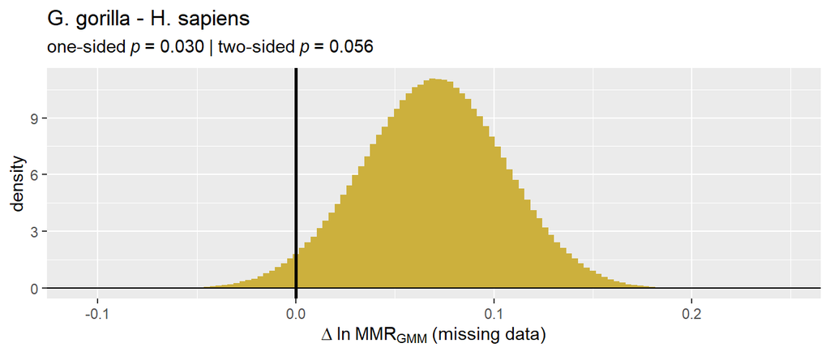

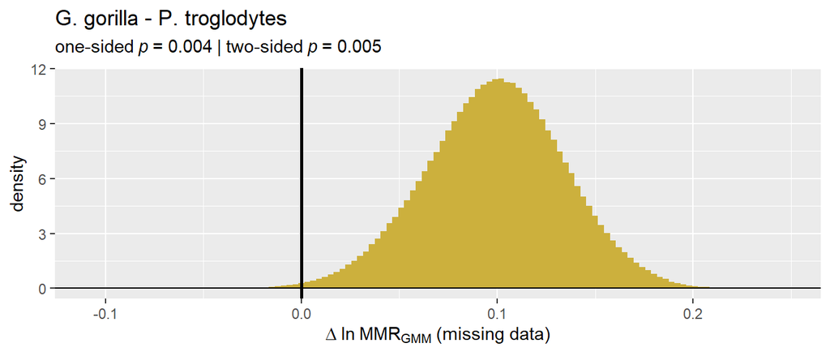

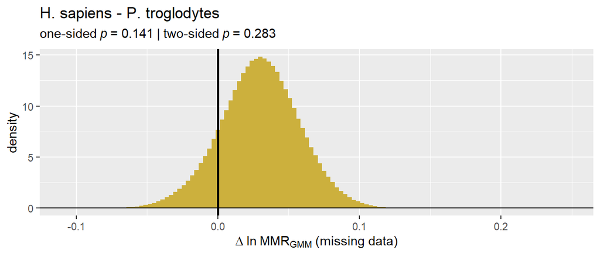

```r
plot(test_fossil_multi, est=2, type="diff",
     gridplot=FALSE, useradvance=FALSE)
```

### 5.2.5 Using `SSDtest()` with missing data in multiple fossil samples (multivariate)

Finally, we may want to include two or more fossil samples in the same set of significance tests. In order to allow for direct comparison of estimates across all fossil samples, the same missing data structure must be imposed on all samples, fossil and comparative alike. This follows the procedure developed in Gordon (2025b), which downsamples within each variable to the sample size for that variable in the fossil sample with the smallest sample for that particular variable. See Gordon (2025b) for a more detailed explanation of this procedure.

```r
test_2fossil_multi <- SSDtest(
     fossil=list("A. afarensis"=GordonAJBA[GordonAJBA$Species=="A. afarensis", SSDvars],
                 "A. africanus"=GordonAJBA[GordonAJBA$Species=="A. africanus", SSDvars]),
     comp=list("G. gorilla"=GordonAJBA[GordonAJBA$Species=="Gorilla gorilla", SSDvars],
               "H. sapiens"=GordonAJBA[GordonAJBA$Species=="Homo sapiens", SSDvars],
               "P. troglodytes"=GordonAJBA[GordonAJBA$Species=="Pan troglodytes", SSDvars]),
     fossilsex=NULL,
     compsex=list("G. gorilla"=GordonAJBA[GordonAJBA$Species=="Gorilla gorilla", "Sex"],
                  "H. sapiens"=GordonAJBA[GordonAJBA$Species=="Homo sapiens", "Sex"],
                  "P. troglodytes"=GordonAJBA[GordonAJBA$Species=="Pan troglodytes", "Sex"]),
     methsUni=c("MMR", "BDI"),
     methsMulti=c("GMM"),
     exactcomp = FALSE,
     exactfossil = TRUE,
     datastruc="both",
     nResamp=nResample)
```

Let’s take a look at `test_2fossil_multi`.

```r
test_2fossil_multi
```

```
#>         SSDtest Object
#>
#> Comparative data set:
#>          sample n female n male n unspecified
#>    A. afarensis        0      0            15
#>    A. africanus        0      0            24
#>      G. gorilla       24     24             0
#>      H. sapiens       24     24             0
#>  P. troglodytes       24     24             0
#>   number of variables: 6
#>   variable names: HUMHEAD, RADTV, FEMHEAD, FEMSHAFT0.5, DISTFEM0.5, DISTTIB0.5
#> SSD estimate methods (univariate):
#>   MMR, BDI
#> SSD estimate methods (multivariate):
#>   GMM
#> Centering algorithms:
#>   geometric mean
#> Multivariate sampling with complete or missing data:
#>   complete and missing
#> Number of unique combinations of univariate method, multivariate method,
#>     centering algorithm, and complete or missing data structure: 4
#>
#> Resampling data structure:
#>          sample n resampled data sets resampling type            sampling
#>    A. afarensis                   336           exact without replacement
#>    A. africanus                 12870           exact without replacement
#>      G. gorilla                  1000     Monte Carlo without replacement
#>      H. sapiens                  1000     Monte Carlo without replacement
#>  P. troglodytes                  1000     Monte Carlo without replacement
#>   missing data resampling structure:
#>     sampling variable-specific number of individuals for each variable
#>   number of resampled individuals by variable in each resampled data set:
#>     HUMHEAD: 2
#>     RADTV: 2
#>     FEMHEAD: 4
#>     FEMSHAFT0.5: 2
#>     DISTFEM0.5: 2
#>     DISTTIB0.5: 3
#>   other resampling parameters:
#>     ratio variables (if present): natural log of ratio
```

[output cut: 67 more lines]

```
#> A. africanus - P. troglodytes                       NA                  0.0010
#> G. gorilla - H. sapiens                         0.0004                  0.2220
#> G. gorilla - P. troglodytes                     0.0000                  0.0777
#> H. sapiens - P. troglodytes                     0.1598                  0.5298
#>                               BDI:GMM:geomean:complete BDI:GMM:geomean:missing
#> A. afarensis - A. africanus                         NA                  0.0262
#> A. afarensis - G. gorilla                           NA                  0.0704
#> A. afarensis - H. sapiens                           NA                  0.0000
#> A. afarensis - P. troglodytes                       NA                  0.0000
#> A. africanus - G. gorilla                           NA                  0.7047
#> A. africanus - H. sapiens                           NA                  0.0112
#> A. africanus - P. troglodytes                       NA                  0.0009
#> G. gorilla - H. sapiens                         0.0023                  0.2396
#> G. gorilla - P. troglodytes                     0.0000                  0.0870
#> H. sapiens - P. troglodytes                     0.1648                  0.5368
```

Here we can see that we have different numbers of resampled data sets for our two fossil samples because exact resampling was used for them, sampling each unique resampled data set exactly once. All comparative taxa share the same number of Monte Carlo resampled data sets as specified by the argument `nResamp`. Also, notice that the missing data resampling structure is quite different from the single fossil sample case: now it is “sampling variable-specific number of individuals for each variable,” and below that is reported the sample size used for each variable in each iteration of the resampling procedure.

Aside from those differences, the type of information reported is the same as in the single fossil sample example, and the structure of the object is the same. We can also plot it in the same way:

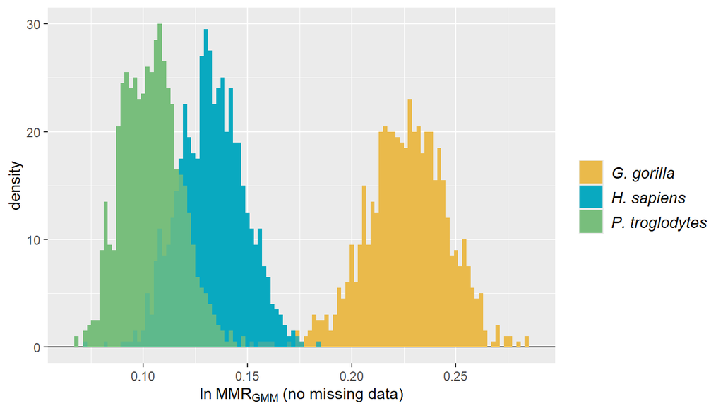

```r
plot(test_2fossil_multi, groupcols=speciescolors)
```

However, because both fossil samples are resampled, we now have distributions for both of them when we plot estimates based on missing data.

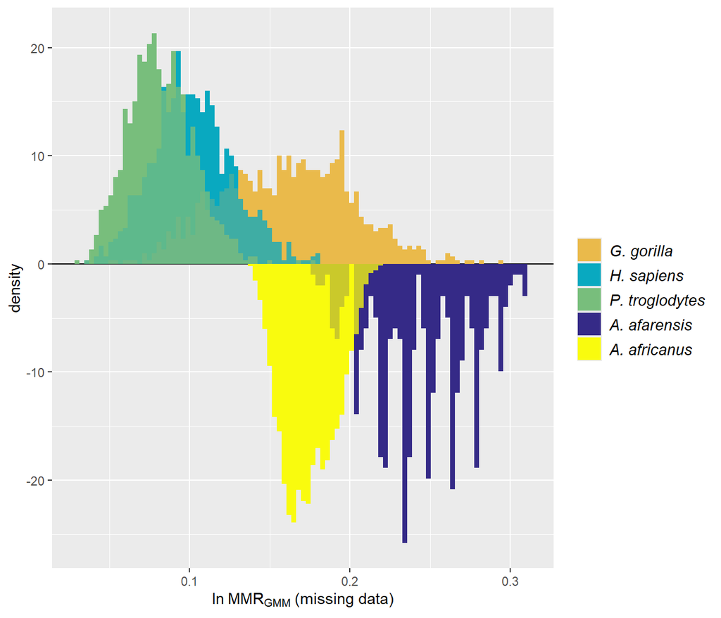

```r
plot(test_2fossil_multi, est=2,
     groupcols=speciescolors, invert=c(1,2)) # invert first and second sample distributions
```

And finally, we can again plot differences in resampled estimates.

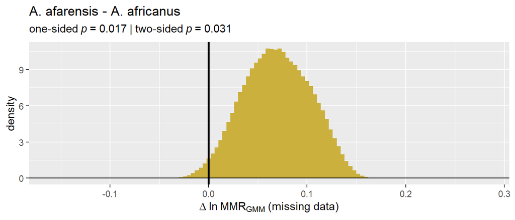

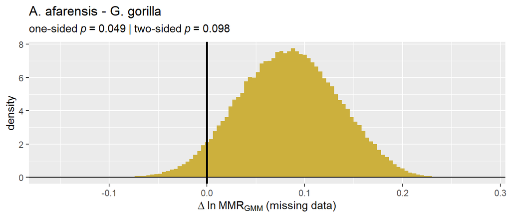

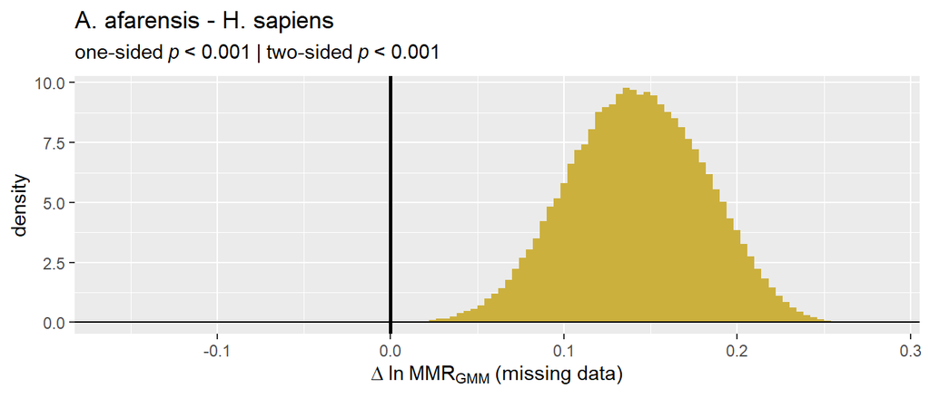

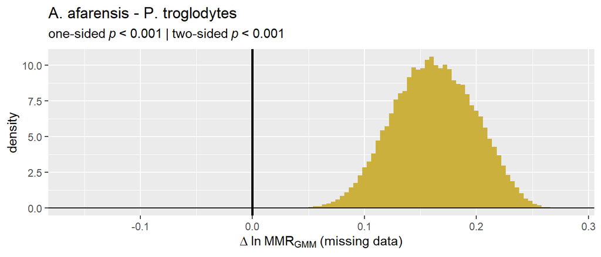

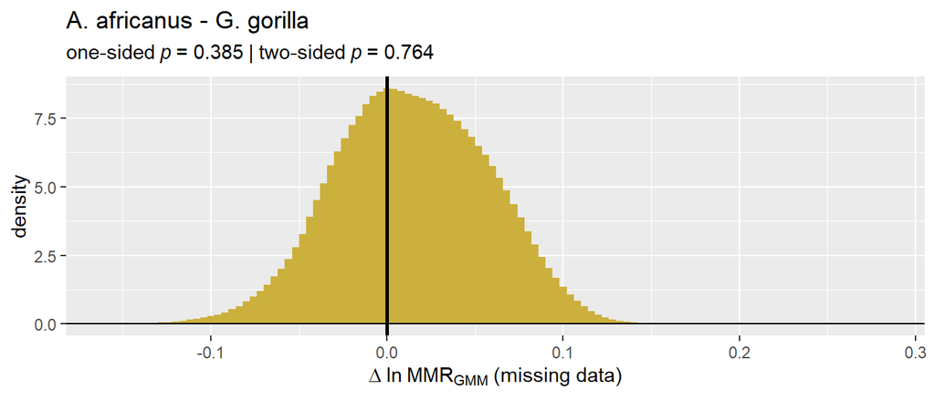

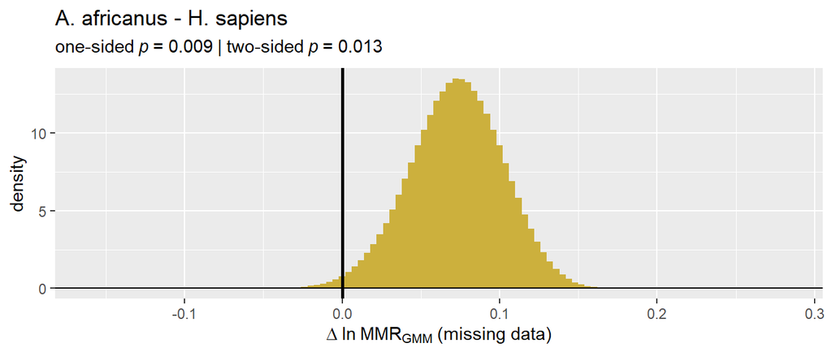

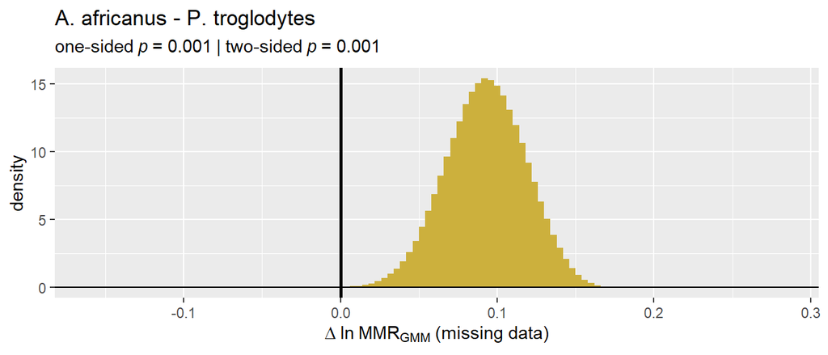

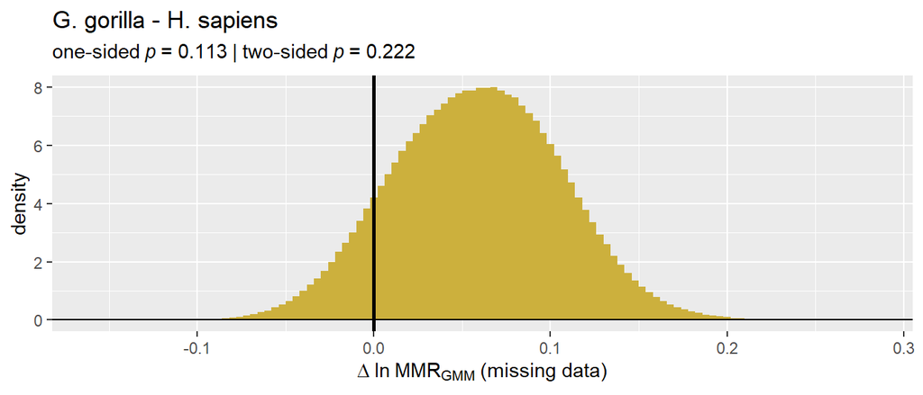

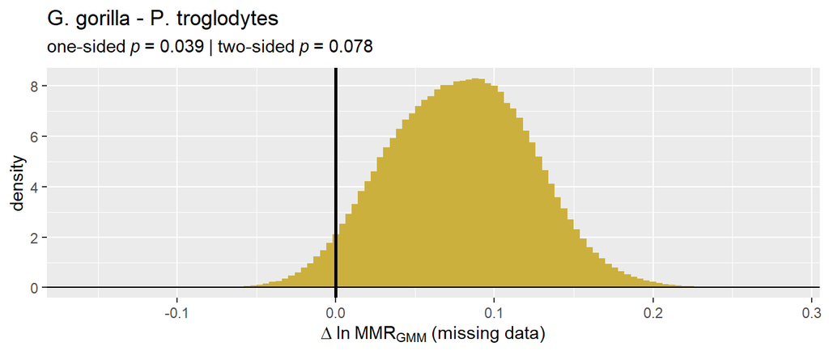

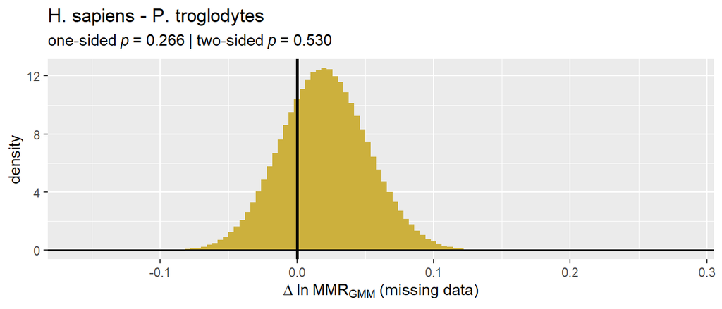

```r
plot(test_2fossil_multi, est=2, type="diff",
     gridplot=FALSE, useradvance=FALSE)
```

# 6 Useful? Please cite it!

Further information about all of these functions can be found in their help pages. To get the full index of help pages for this package, use `help(package="dimorph")`.

Also, if you use this package in your work, please use the following citations:

```r
citation(package="dimorph")
```

```
#>
#>   Gordon AD (2025). "Interpreting statistical significance in hominin
#>   dimorphism: Power and Type I error rates for resampling tests of
#>   univariate and missing-data multivariate size dimorphism estimation
#>   methods in the fossil record." _Journal of Human Evolution_, *199*,
#>   103630. doi:10.1016/j.jhevol.2024.103630
#>   <https://doi.org/10.1016/j.jhevol.2024.103630>.
#>
#>   Gordon AD (2025). "Sexual size dimorphism in Australopithecus:
#>   postcranial dimorphism differs significantly among Australopithecus
#>   afarensis, A. africanus, and modern humans despite low-power
#>   resampling analyses." _American Journal of Biological Anthropology_,
#>   *187*, e70093. doi:10.1002/ajpa.70093
#>   <https://doi.org/10.1002/ajpa.70093>.
#>
#> To see these entries in BibTeX format, use 'print(<citation>,
#> bibtex=TRUE)', 'toBibtex(.)', or set
#> 'options(citation.bibtex.max=999)'.
```

And if you use any of the data sets in this package, please refer to the help page for that data set for the proper citations.

# 7 References

Campisano CJ. (2007) *Tephrostratigraphy and hominin paleoenvironments of the Hadar Formation, Afar Depression, Ethiopia*. Ph.D. thesis. Rutgers, The State University of New Jersey. https://www.proquest.com/docview/304805803

Godfrey LR, Lyon SK, Sutherland MR. (1993) Sexual dimorphism in large-bodied primates: The case of the subfossil lemurs. *American Journal of Physical Anthropology*. 90:315-334. https://doi.org/10.1002/ajpa.1330900306

Gordon AD. (2025a) Interpreting statistical significance in hominin dimorphism: Power and Type I error rates for resampling tests of univariate and missing-data multivariate size dimorphism estimation methods in the fossil record. *Journal of Human Evolution*. 199:103630. https://doi.org/10.1016/j.jhevol.2024.103630

Gordon AD. (2025b) Sexual size dimorphism in *Australopithecus*: postcranial dimorphism differs significantly among *Australopithecus afarensis*, *A. africanus*, and modern humans despite low-power resampling analyses. *American Journal of Biological Anthropology*. 187:e70093. https://onlinelibrary.wiley.com/doi/10.1002/ajpa.70093

Gordon AD, Green DJ, Richmond BG. (2008) Strong postcranial size dimorphism in *Australopithecus afarensis*: Results from two new resampling methods for multivariate data sets with missing data. *American Journal of Physical Anthropology*. 135:311-328. https://doi.org/10.1002/ajpa.20745

Gordon AD, Green DJ, Jungers WL, Richmond BG. (2020) Limb proportions and positional behavior: revisiting the theoretical and empirical underpinnings for locomotor reconstruction in *Australopithecus africanus*. In Zipfel B, Richmond BG, and Ward CV, eds.: *Hominid Postcranial Remains from Sterkfontein, South Africa, 1936-1995*. Advances in Human Evolution Series. Oxford University Press. pp. 321-334. [Book Chapter](https://doi.org/10.1093/oso/9780197507667.003.0017) | [Appendix III](https://doi.org/10.1093/oso/9780197507667.005.0003) | [Appendix IV](https://doi.org/10.1093/oso/9780197507667.005.0004)

Josephson SC, Juell KE, Rogers AR. (1996) Estimating sexual dimorphism by method-of-moments. *American Journal of Physical Anthropology*. 100:191-206. https://doi.org/10.1002/(SICI)1096-8644(199606)100:2<191::AID-AJPA3>3.0.CO;2-0

Lee S-H. (2001) Assigned Resampling Method: A new method to estimate size sexual dimorphism in samples of unknown sex. *Anthropological Review*. 64:21–39. https://doi.org/10.18778/1898-6773.64.02

Reno PL, Meindl RS, McCollum MA, Lovejoy CO. (2003) Sexual dimorphism in *Australopithecus afarensis* was similar to that of modern humans. *Proceedings of the National Academy of Sciences*. 100:9404-9409. https://doi.org/10.1073/pnas.1133180100

Sasaki T, Semaw S, Rogers MJ, Simpson SW, Beyene Y, Asfaw B, White TD, Suwa G. (2021) Estimating sexual size dimorphism in fossil species from posterior probability densities. *Proceedings of the National Academy of Sciences*. 118:e2113943118. https://doi.org/10.1073/pnas.2113943118

Sokal RR, Braumann CA (1980) Significance tests for coefficients of variation and variability profiles. *Systematic Zoology*. 29:50–66. https://doi.org/10.2307/2412626

Smith RJ. (1999) Statistics of sexual size dimorphism. *Journal of Human Evolution*. 36:423-458. https://doi.org/10.1006/jhev.1998.0281